Skip to contents

# 🔍 Data quality, diversity and fleets

Source: [`vignettes/articles/quality-diversity-fleets.Rmd`](https://github.com/Linbojun99/faofishingreport/blob/main/vignettes/articles/quality-diversity-fleets.Rmd)

📦 **Data**: [FAO Global Capture Production](https://www.fao.org/fishery/collection/capture/en), release **2026.1.0** (published by FAO on 2026-03-30; catches 1950–2024), downloaded from Capture_2026.1.0.zip. Licence [CC BY 4.0](https://creativecommons.org/licenses/by/4.0/). `fao_data_info()` shows the release you use and how to cite it.

Like the analyses of 📈 Composition, stock status and trends, these functions take any catch data: a fishing area from `fishing_area_data()`, or any subset of `load_fao_data()`. Their charts are saved in `figures/png/summary/` and their tables in `tables/`, with the name of the area at the start of the file names (or `label`), and they return their results invisibly.

```r
FAO27 <- fishing_area_data("Atlantic, Northeast")
```

## ⚙️ Common arguments

All four functions have these arguments; the tables of each function list only its own.

| Argument | Meaning | Default |
| --- | --- | --- |
| `area_data` | FAO catch data: `fishing_area_data()$area_data`, or any subset of `load_fao_data()` (e.g. one country, or several fishing areas) | required |
| `plot` | Save the charts in `figures/png/summary/` | `TRUE` |
| `table` | Save the tables in `tables/` | `TRUE` |
| `lang` | Language of the chart text and names: `"en"`, `"zh"` or `"both"` | `NULL`: the language of `fao_settings()` (`"en"` unless changed) |
| `pptx` | Also save the charts as editable PowerPoint files in `figures/pptx/summary/` | `FALSE`; `fao_settings(pptx = TRUE)` changes it for all functions |
| `plot_show` | Also draw each chart in the plot window (e.g. the Plots pane of RStudio) as it is saved | `FALSE`, or `plot_show` of `fao_settings()` |
| `label` | Name at the start of the output file names | `NULL`: the fishing area of the data (or its country; `"selected_data"` for several areas and countries) |

## 🧪 Data quality

`data_quality()` shows two aspects of the statistics over time:

- the share of the catch **reported officially** (FAO status flag A), the share **estimated** by the country or imputed by FAO (flags E and I), and the share with other flags (e.g. provisional or negligible values);
- the share of the catch **identified to species**, genus, family, or only to an order or a higher group such as “Marine fishes nei”, from the FAO taxonomic codes.

```r
quality <- data_quality(FAO27$area_data)
```

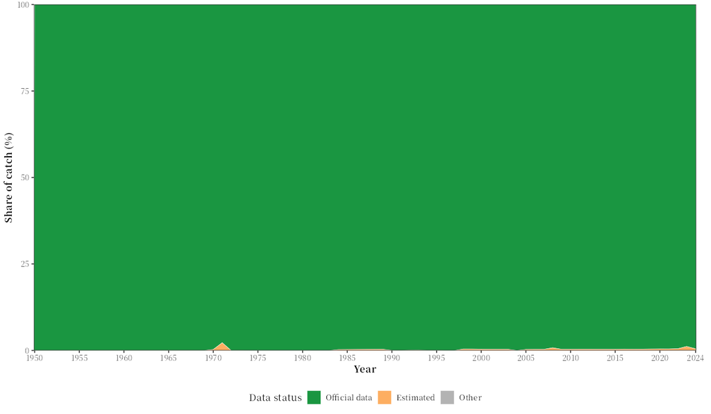

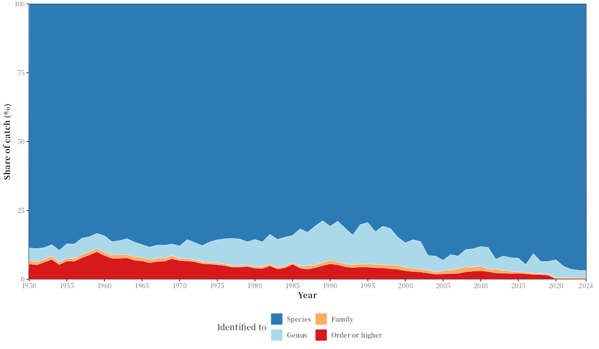

A large estimated share in the latest years usually means that FAO has not yet received the national reports; these values are often revised in the next release (Garibaldi 2012). The country table shows, for the countries with the largest catch in the last five years, how much of their catch in those years was estimated and how much identified to species:

```r
show_table(quality$countries, digits = 1)
```

| country | country_en | catch_last_5_years | estimated_pct | species_level_pct |
| --- | --- | --- | --- | --- |
| Norway | Norway | 11327375 | 0.0 | 95.5 |
| Iceland | Iceland | 6329277 | 0.0 | 99.4 |
| Russian Federation | Russian Federation | 4811200 | 0.0 | 99.6 |
| United Kingdom | United Kingdom | 3340084 | 0.0 | 96.9 |
| Faroe Islands | Faroe Islands | 3252896 | 0.0 | 98.1 |
| Denmark | Denmark | 2606338 | 0.0 | 79.8 |
| France | France | 1824629 | 0.2 | 91.0 |
| Netherlands (Kingdom of the) | Netherlands (Kingdom of the) | 1327367 | 0.0 | 100.0 |
| Spain | Spain | 1271825 | 0.0 | 94.4 |
| Ireland | Ireland | 1142570 | 16.4 | 85.8 |

| Argument | Meaning | Default |
| --- | --- | --- |
| `top_n` | Number of countries in the country table | `10` |
| `area_data`, `plot`, `table`, `lang`, `pptx`, `label` | See Common arguments |  |

Output: `<label>_data_quality_status_share.png` and `<label>_data_quality_taxon_share.png`, and the tables `<label>_data_quality_status.csv`, `..._taxon.csv` and `..._countries.csv`; the function returns `data_status`, `taxon_level` (yearly catch by category) and `countries`.

The FAO statistics are the catches reported by countries (and estimated by FAO when no report arrives). Catch reconstructions that add estimates of unreported catches and discards found global marine catches higher than reported, and declining more strongly since their peak (Pauly and Zeller 2016). The data quality charts show how the reported statistics were made, not how complete they are.

## 🌈 Diversity and concentration

`diversity_concentration()` computes, for each year:

| Indicator | Column | Calculation |
| --- | --- | --- |
| Number of species reported | `n_species` | Items identified to species with catch |
| Number of countries | `n_countries` | Countries with catch |
| Shannon diversity (Shannon 1948) | `shannon_species` | $H = -\sum_i p_i \ln p_i$, with $p_i$ the share of species item $i$ (all items, including “nei” groups) in the year’s catch |
| HHI of species / countries (Rhoades 1993) | `hhi_species`, `hhi_countries` | $\text{HHI} = \sum_i (100\,p_i)^2$, from 0 to 10 000 |
| Top-N share | `top5_species_pct`, `top5_countries_pct` | Share (%) of the `top_n` largest species items or countries (the column names follow `top_n`) |

```r
diversity <- diversity_concentration(FAO27$area_data, top_n = 5)
```

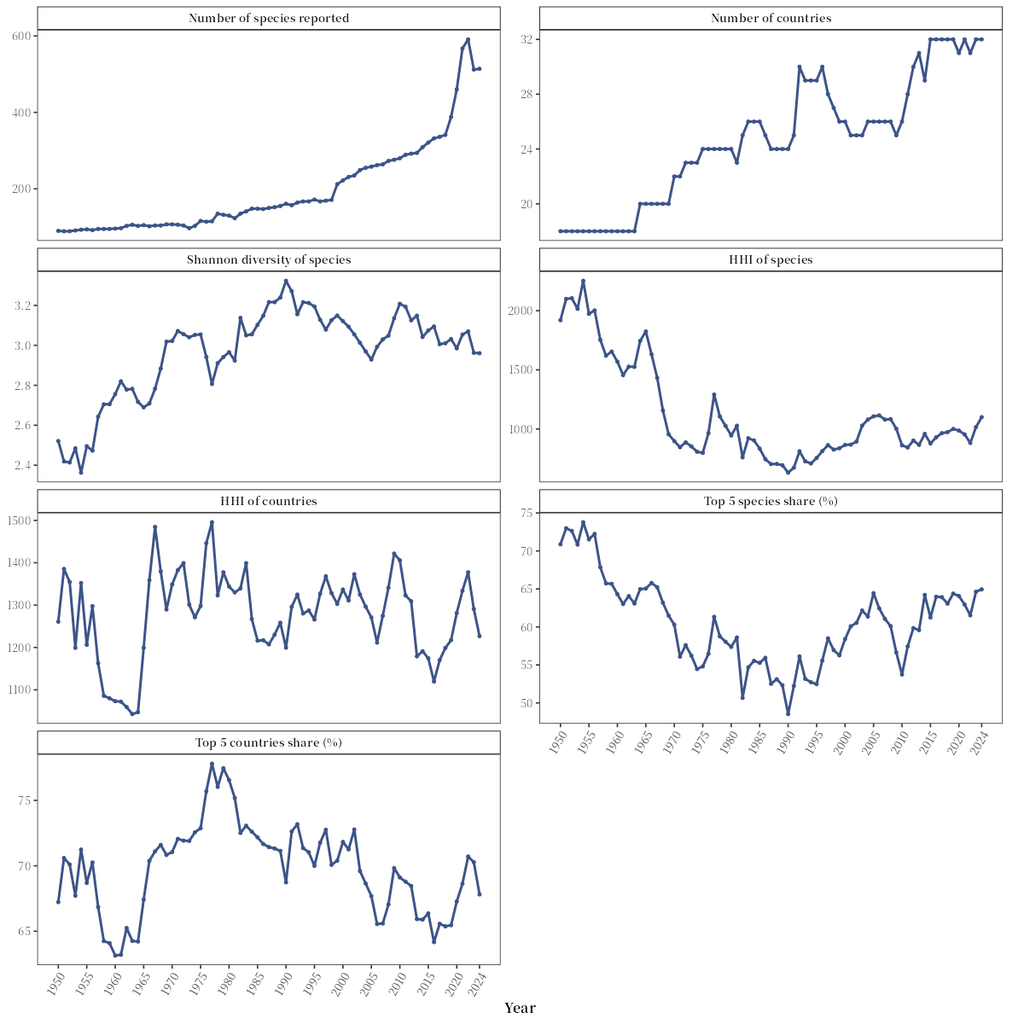

```r
show_table(subset(diversity, Year %in% c(1970, 1990, 2010, max(Year))), digits = 2)
```

|  | Year | n_species | n_countries | shannon_species | hhi_species | hhi_countries | top5_species_pct | top5_countries_pct |
| --- | --- | --- | --- | --- | --- | --- | --- | --- |
| 1970 | 1970 | 107 | 22 | 3.02 | 897.68 | 1,348.67 | 60.29 | 71.05 |
| 1990 | 1990 | 161 | 24 | 3.32 | 631.00 | 1,199.47 | 48.53 | 68.73 |
| 2010 | 2010 | 280 | 26 | 3.21 | 862.25 | 1,405.73 | 53.74 | 69.11 |
| 2024 | 2024 | 514 | 32 | 2.96 | 1,100.44 | 1,226.80 | 64.95 | 67.81 |

| Argument | Meaning | Default |
| --- | --- | --- |
| `top_n` | Number of largest species items and countries in the top share | `5` |
| `area_data`, `plot`, `table`, `lang`, `pptx`, `label` | See Common arguments |  |

Output: `<label>_diversity.png` (all indicators) and the table `<label>_diversity.csv`; the function returns a data frame with one row per year.

**Reading the indicators.** A higher Shannon index means more species items and a more even catch; its maximum is $\ln S$ for $S$ items. In the US merger guidelines (U.S. Department of Justice and Federal Trade Commission 2010), an HHI below 1 500 is unconcentrated, 1 500 to 2 500 moderately and above 2 500 highly concentrated. For example, three species with shares of 50%, 30% and 20% give $H = 1.03$ and $\text{HHI} = 50^2 + 30^2 + 20^2 = 3\,800$.

The indicators use FAO species items, including “nei” groups. When FAO splits a “nei” group into species, Shannon diversity rises and HHI falls even if nothing changed at sea. Country indicators change when countries split, e.g. the USSR in 1991.

## 🏳️ Country groups

`country_group_summary()` sums the catch by groups of countries from the FAO country list: **World Bank income group**, **continent** or **region**. It saves a chart of the catch of each group and one of its share, and a table by decade like that of `species_group_composition()`.

```r
income <- country_group_summary(FAO27$area_data, group = "income")
```

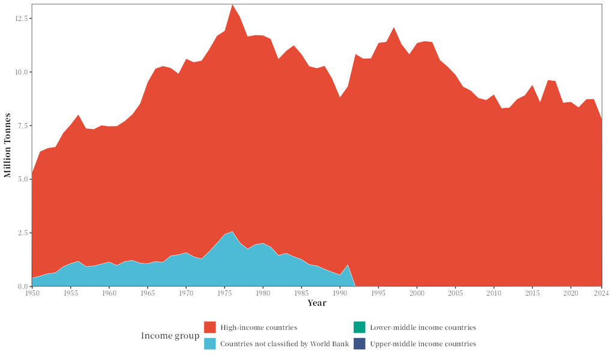

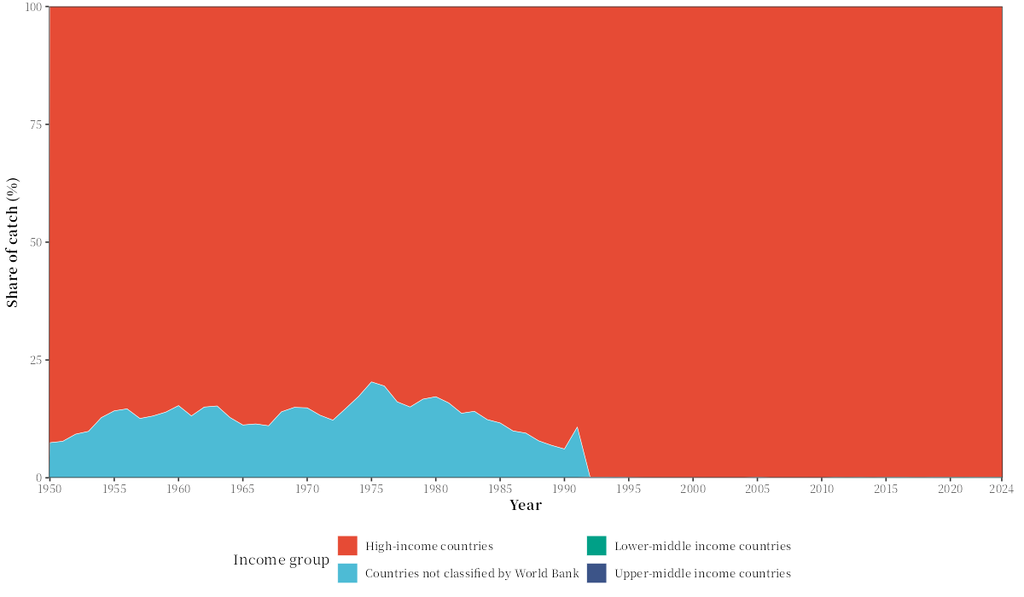

```r
country_group_summary(FAO27$area_data, group = "region", top_n = 6, lang = "zh")
```

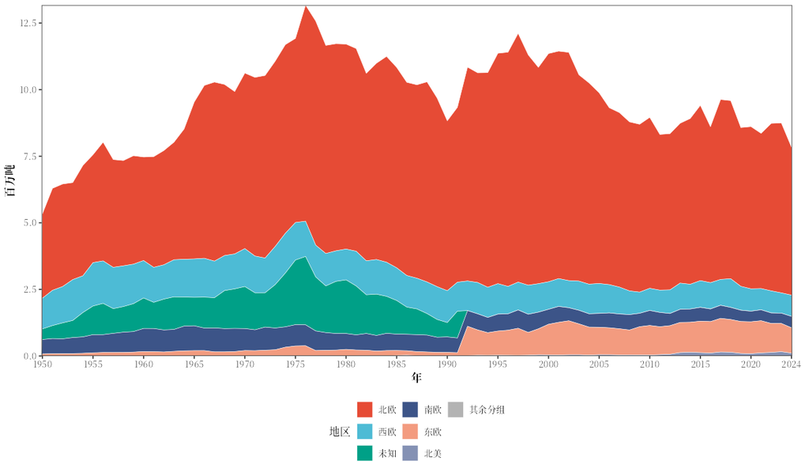

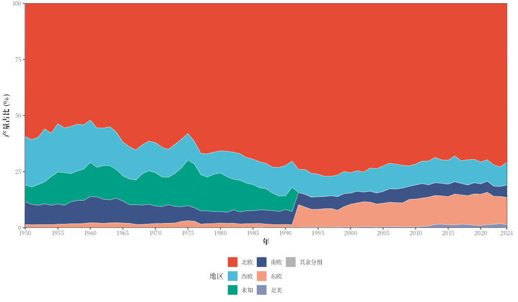

| Argument | Meaning | Default |
| --- | --- | --- |
| `group` | `"income"` (World Bank income groups), `"continent"` or `"region"` | `"income"` |
| `top_n` | Number of groups shown separately; the others are combined | `8` |
| `area_data`, `plot`, `table`, `lang`, `pptx`, `label` | See Common arguments |  |

Output: `<label>_country_income.png` (or `_continent`, `_region`) and `..._share.png`, and the table `<label>_country_income.csv`; the function returns `yearly` and `table`.

## 🚢 Coastal countries and distant-water fleets

`coastal_distant()` splits the catch between countries that **border** the fishing area and **distant-water** fleets from elsewhere, and shows the main distant-water countries.

A country is coastal to an area if its land (including overseas territories, from the Natural Earth map units) lies within 20 km of the FAO area boundary (the FAO major fishing areas of the CWP handbook). Former countries such as the USSR take the coastline of their successor states. In area 34 (Eastern Central Atlantic), for example, Spain and Portugal count as coastal because of the Canary Islands and Madeira. Catch reported as “Other nei” is shown as unknown.

```r
fleets <- coastal_distant(FAO27$area_data)
```

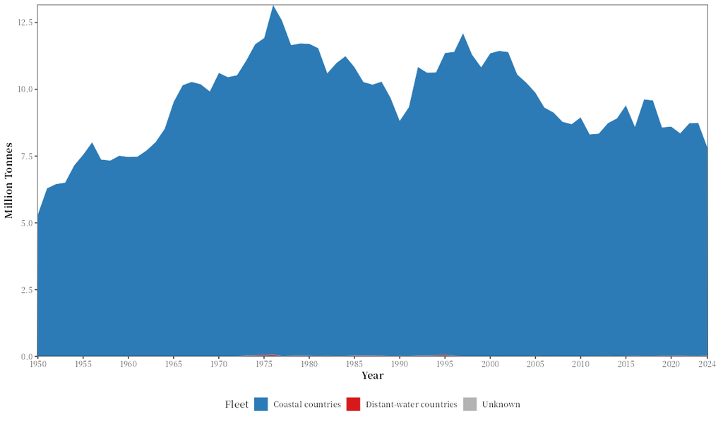

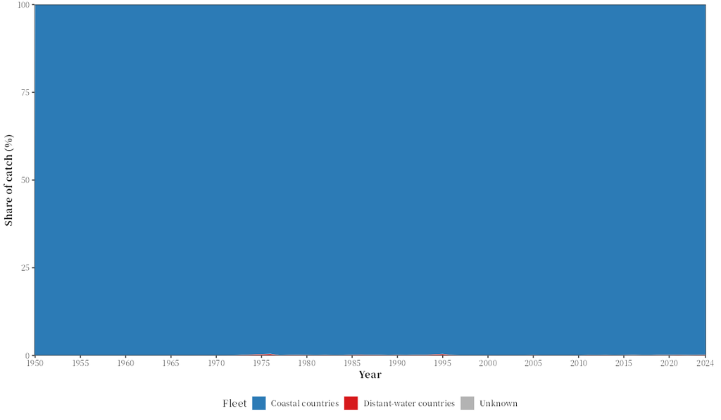

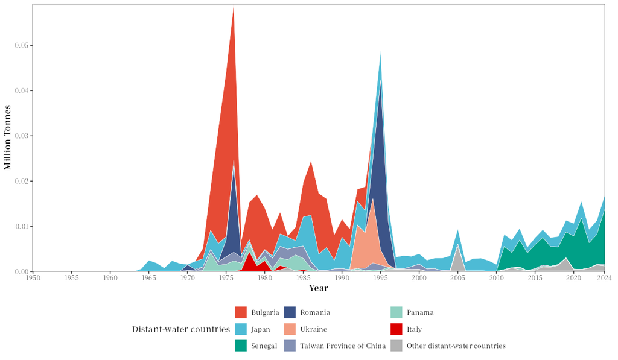

```r
show_table(fleets$table, digits = 0)
```

| Fleet | 1950s | 1960s | 1970s | 1980s | 1990s | 2000s | 2010s | 2020s | 2020 | 2021 | 2022 | 2023 | 2024 | share_2024_pct |
| --- | --- | --- | --- | --- | --- | --- | --- | --- | --- | --- | --- | --- | --- | --- |
| Coastal countries | 6,956,166 | 8,930,049 | 11,522,278 | 10,722,687 | 10,713,646 | 10,080,097 | 8,899,457 | 8,445,147 | 8,598,826 | 8,343,100 | 8,719,874 | 8,738,529 | 7,825,406 | 100 |
| Distant-water countries | 0 | 1,000 | 20,186 | 14,021 | 16,346 | 3,569 | 7,511 | 12,742 | 10,649 | 15,624 | 9,353 | 11,298 | 16,787 | 0 |
| Unknown | 0 | 0 | 0 | 2 | 107 | 0 | 1,144 | 930 | 2,227 | 2 | 2,420 | 2 | 2 | 0 |

| Argument | Meaning | Default |
| --- | --- | --- |
| `top_n` | Number of distant-water countries shown separately | `8` |
| `area_data`, `plot`, `table`, `lang`, `pptx`, `label` | See Common arguments |  |

The analysis works for marine areas; inland areas in the data are left out with a message. Output: `<label>_coastal_distant.png` and `..._share.png` (coastal, distant-water and unknown catch), `<label>_coastal_distant_countries.png` (main distant-water countries), and the tables `<label>_coastal_distant.csv` and `..._countries.csv`; the function returns `yearly`, `distant` and `table`. The profiles of the main distant-water countries are in 🔬 Shocks, collapses, synchrony and fleets.

## 📝 In the Word report

`fao_report()` writes data quality, diversity and concentration, and coastal and distant-water fleets into the Word report of a fishing area (see 📝 Assessment report: Word, LaTeX and PDF): they are the sections `quality`, `diversity` and `fleets`, all on by default. Their settings are given with the section name as prefix (`quality_` for `data_quality()`, `diversity_` for `diversity_concentration()`, `fleets_` for `coastal_distant()`), and a section is left out with `FALSE`:

```r
fao_report(27, diversity_top_n = 3, fleets = FALSE)
```

`country_group_summary()` is not part of the report.

## 📖 References

CWP (Coordinating Working Party on Fishery Statistics). *CWP Handbook of Fishery Statistics*: Main water areas (FAO major fishing areas). Rome: FAO. https://www.fao.org/cwp-on-fishery-statistics/handbook/general-concepts/main-water-areas/en/

FAO (2026). *Global Capture Production 1950–2024*, release 2026.1.0. In: Fisheries and Aquaculture. Rome: FAO. https://www.fao.org/fishery/collection/capture/en. Licence: CC BY 4.0. Release file: https://www.fao.org/fishery/static/Data/Capture_2026.1.0.zip

Garibaldi, L. (2012). The FAO global capture production database: a six-decade effort to catch the trend. *Marine Policy* 36: 760–768. [doi:10.1016/j.marpol.2011.10.024](https://doi.org/10.1016/j.marpol.2011.10.024)

Natural Earth. Free vector and raster map data at 1:10m, 1:50m and 1:110m scales. https://www.naturalearthdata.com/

Pauly, D. and Zeller, D. (2016). Catch reconstructions reveal that global marine fisheries catches are higher than reported and declining. *Nature Communications* 7: 10244. [doi:10.1038/ncomms10244](https://doi.org/10.1038/ncomms10244)

Rhoades, S.A. (1993). The Herfindahl-Hirschman index. *Federal Reserve Bulletin* 79(3): 188–189.

Shannon, C.E. (1948). A mathematical theory of communication. *Bell System Technical Journal* 27: 379–423. [doi:10.1002/j.1538-7305.1948.tb01338.x](https://doi.org/10.1002/j.1538-7305.1948.tb01338.x)

U.S. Department of Justice and Federal Trade Commission (2010). *Horizontal Merger Guidelines*, section 5.3 (market concentration). Washington, DC. https://www.justice.gov/atr/horizontal-merger-guidelines-08192010